# Wunderkammer

Choreographie von *Marcos Morau*  
Musik von *Clara Aguilar* und *Ben Meerwein*

*Empfohlen ab 16 Jahren*

Marcos Morau, preisgekrönter Choreograph und derzeit «Artist in Residence» beim Staatsballett Berlin, ruft mit seinen unverwechselbaren Bühnenwelten vertraute Orte ins Gedächtnis, die er zugleich in traumartige und unwirkliche Sphären versetzt. Der Titel *Wunderkammer* verweist auf die historischen Wunderkammern – auch Kuriositätenkabinette genannt –, die im Europa der Renaissance und des Barock als Sammlungen außergewöhnlicher und ‹kurioser› Objekte dienten. In diesen Wunderkammern wurde ‹Fremdartiges› und Faszinierendes aus Wissenschaft, Kunst und Natur zusammengetragen und vereint. Marcos Morau greift dieses Thema auf und verwandelt die Bühne in seinem Werk zu einem Ort voller Überraschungen und unerwarteter Perspektiven, um seine persönliche Formulierung der Frage nach dem ‹Fremden› aufzuwerfen. Wie es typisch für ihn ist, reflektiert er zugleich über die Theaterbühne selbst, und greift auf universelle Themen zurück, nämlich die Sehnsucht nach Zugehörigkeit und das Bedürfnis, die eigene Identität in einer immer komplexer werdenden Welt zu definieren. So wird *Wunderkammer* zugleich zu einem szenischen Spiegel unserer Zeit.

___

*Hinweis: Während der Aufführung werden unvermittelte und starke Sound-Effekte ausgelöst, die unter Umständen ein gewohntes Maß überschreiten.*

Videos

[figure not shown]

Termine

2025

So.30.11.2025(NV)Restkarten

So.30.11.2025(AV)Restkarten

2026

Sa.11.4.2026Tickets kaufen

Fr.17.4.2026Tickets kaufen

Do.23.4.2026Tickets kaufen

Info

Komische Oper Berlin @ Schillertheater

15.00 Uhr

1 h 10 min ohne Pause

[Termin speichern](https://www.staatsballett-berlin.de/system/sites/ical/content/event/553.html)

12,00 – 98,00

Einführung zum Stück jeweils 45 Minuten vor der Veranstaltung

Familienvorstellung

Kinder und Jugendliche unter 18 Jahren zahlen bei Familienvorstellungen auf allen Plätzen 10 €.

### Besetzung30.11.

Choreographie und Inszenierung [Marcos Morau](https://www.staatsballett-berlin.de/kompanie/personen-detail/peid/marcos-morau/1000486.html)  
Choreographische Assistenz [Shay Partush](https://www.staatsballett-berlin.de/kompanie/personen-detail/peid/shay-partush/2001128.html)  
Musik [Clara Aguilar](https://www.staatsballett-berlin.de/kompanie/personen-detail/peid/clara-aguilar/2001247.html) / [Ben Meerwein](https://www.staatsballett-berlin.de/kompanie/personen-detail/peid/ben-meerwein/2001403.html)  
Songtexte [Katja Wiegand](https://www.staatsballett-berlin.de/kompanie/personen-detail/peid/katja-wiegand/2000564.html) / [Ben Meerwein](https://www.staatsballett-berlin.de/kompanie/personen-detail/peid/ben-meerwein/2001403.html) / [Marcos Morau](https://www.staatsballett-berlin.de/kompanie/personen-detail/peid/marcos-morau/1000486.html)  
Bühne [Max Glaenzel](https://www.staatsballett-berlin.de/kompanie/personen-detail/peid/max-glaenzel/2000950.html)  
Kostüme [Silvia Delagneau](https://www.staatsballett-berlin.de/kompanie/personen-detail/peid/silvia-delagneau/2000951.html)  
Licht [cube.bz](https://www.staatsballett-berlin.de/kompanie/personen-detail/peid/cubebz-1/2001248.html)  
Dramaturgie [Katja Wiegand](https://www.staatsballett-berlin.de/kompanie/personen-detail/peid/katja-wiegand/2000564.html)

In den Originalkompositionen sind Ben Meerwein (Gesang) und Clara Aguilar (Stimme) zu hören.

___

Mit freundlicher Unterstützung  
Botschaft von Spanien  
Dr. Gregor Wahl

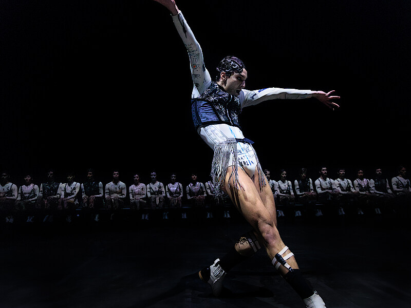

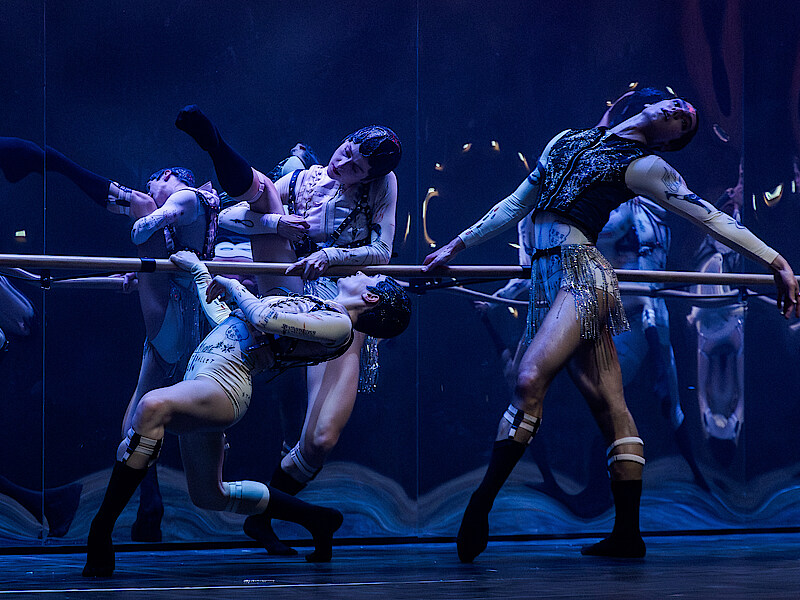

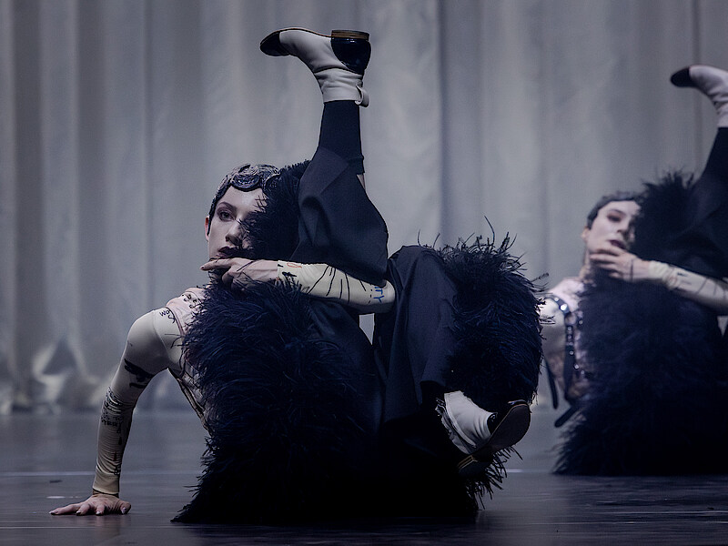

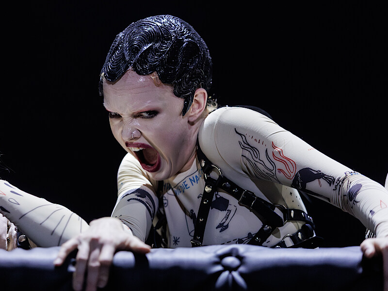

Inara Wheeler, Foto: Yan Revazov

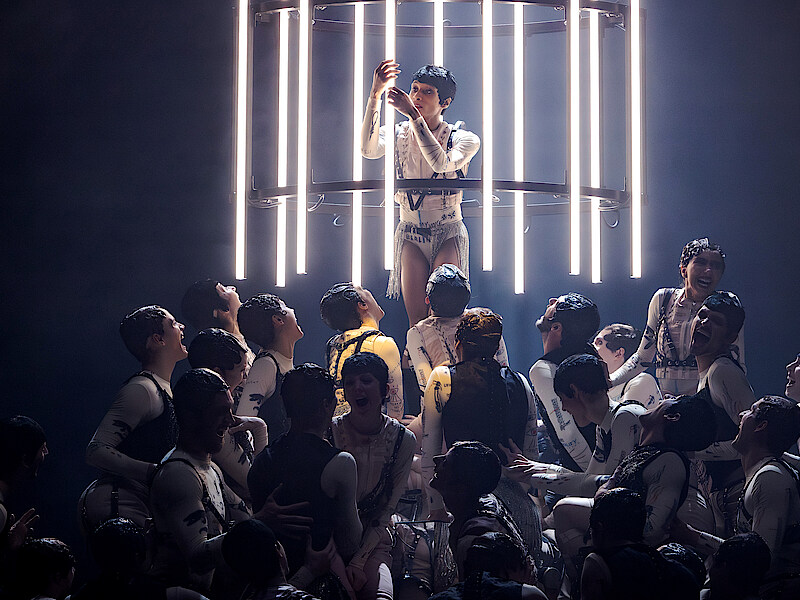

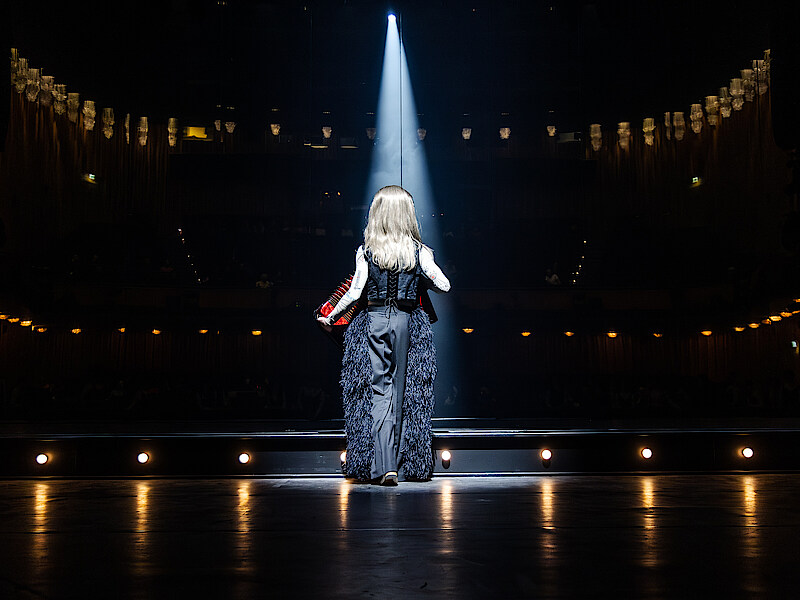

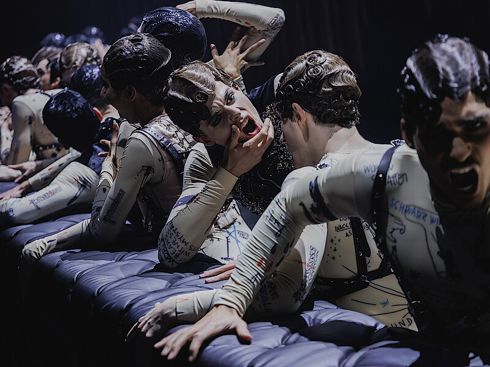

> «Furios, soghaft und voller düsterer Ahnungen. […] Es ist ein Abgesang auf die 20er Jahre und eine ganz große Show.»

##### Berliner Zeitung

> «Das ausdrucksstarke Ensemble vermag zu fesseln.»

##### Tagesspiegel

> «Wandelbar und in den verschiedensten Stilen versiert zeigt sich das glänzend trainierte Staatsballett-Ensemble.»

##### Berliner Morgenpost

> «Marcos Morau huldigt Berlin als Tanzmetropole, greift die Fäden zeitgenössischer und historischer Ästhetiken auf und verdrillt sie zu dichten Szenen.»

##### Der Freitag

> «Ein imposanter Abend mit beeindruckenden Bildern.»

##### Deutsche Bühne

> «Ein starkes Bild für die 1930er-Jahre aber auch für die gesellschaftspolitischen Veränderungen im Europa unserer Zeit. […] Ein Gesamtkunstwerk, das einen 70 Minuten in den Bann zieht.»

##### Tanznetz.de

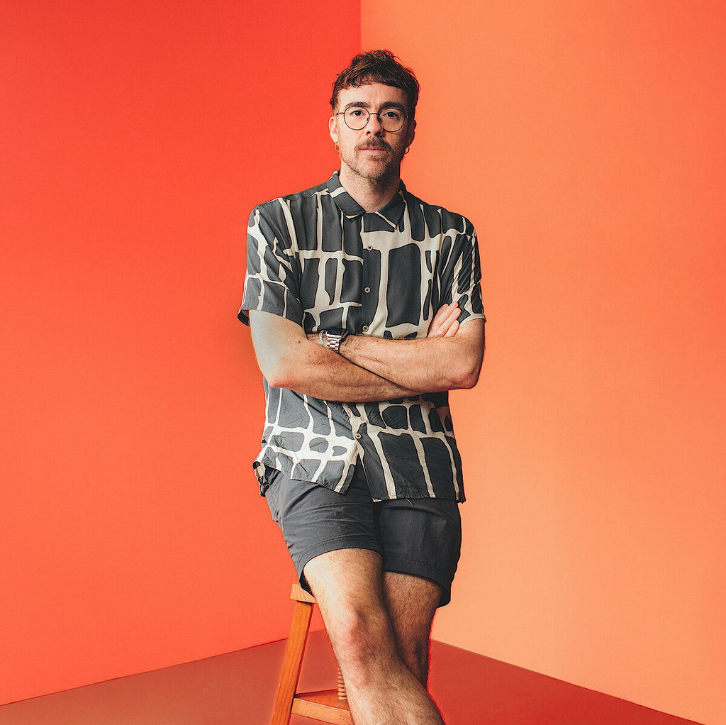

### «Das Theater selbst kann eine bewegte Wunderkammer sein»

###### Marcos Morau im Gespräch

*Staatsballett Berlin (SBB)* Dein neues Stück trägt den deutschen Titel *Wunderkammer*. Wie kam es zu dem Titel und welche Bedeutung hat dieser für dich?

*Marcos Morau (MM)* Titel müssen für mich auf mehreren Ebenen funktionieren: im Klang, in der Bedeutung und in den Assoziationen, die sie hervorrufen. *Wunderkammer* bezieht sich auf historische Kuriositätenkabinette, in denen Sammler ‹exotische› Objekte, Kuriositäten und groteske Artefakte anordneten, die eine Faszination für Abweichung und das Unbekannte widerspiegelten. Mich interessiert, dass der Wert dieser Wunderkammern weniger in den Objekten selbst lag, als in den Geschichten, die sie hervorriefen. Diese Sammlungen verbanden Schönheit und Furcht, Wunder und Fremdheit und enthielten oft ‹Monster›, wie seltene Tiere, anatomische Kuriositäten und Hybride, also Mischformen oder Objekte zwischen Natur und Kunst, Realität und Fantasie. Das waren im Grunde Objekte, die aus dem Kontext sozialer Normen gelöst wurden und die Wahrnehmung des ‹Fremden› herausforderten.

Empfehlungen

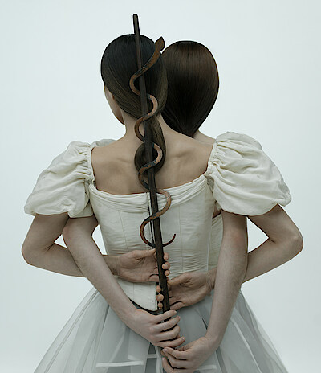

### Fearful Symmetries

Choreographien von *George Balanchine* und *Christian Spuck*

Staatsoper Unter den Linden

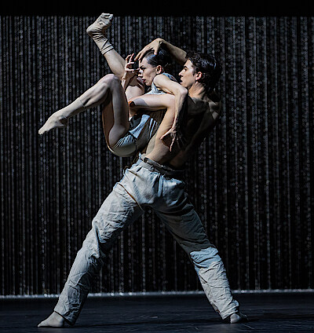

### Gods and Dogs

Choreographien von *Jiří Kylián* und *Crystal Pite*

Staatsoper Unter den Linden

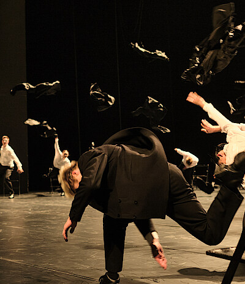

### Minus 16

Choreographien von *Sharon Eyal* und *Ohad Naharin*

Deutsche Oper Berlin